# The Corporate Reputation Mode-1

yunan

2022-10-22

Specifically, it is the so-called Eberl’s (2010) corporate reputation model. The goal of the model is to explain the effects of corporate reputation on customer satisfaction (CUSA) and, ultimately, customer loyalty(CUSL). Corporate reputation represents a company’s overall evaluation by its stakeholders (Helm, Eggert, & Garnefeld, 2010). This construct is measured using two dimensions. One dimension represents cognitive evaluations of the company, which is the company’s competence (COMP). The second dimension captures affective judgments, which determine the company’s likeability (LIKE). Research has shown that the model performs favorably (in terms of convergent validity and predictive validity) compared to alternative reputation measures (Sarstedt,Wilczynski, & Melewar, 2013)

In summary, the simple corporate reputation model has two main **theoretical components**:

*(1) the target constructs of interest – namely, CUSA and CUSL(endogenous constructs), and* (2) the two corporate reputation dimensions COMP

and LIKE (exogenous constructs), which are key determinants of the target constructs. . Figure shows the constructs and their relationships.

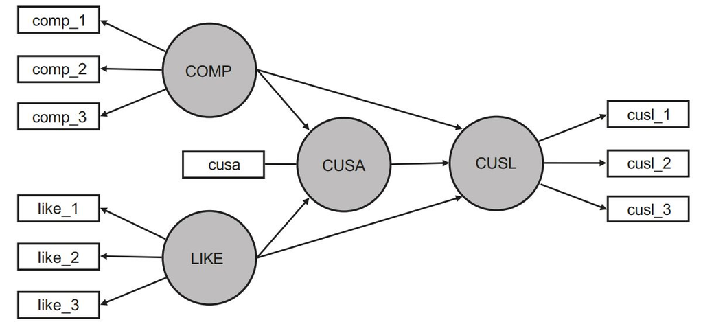

Simple corporate reputation model

And the descriptions on the constructs and indicators

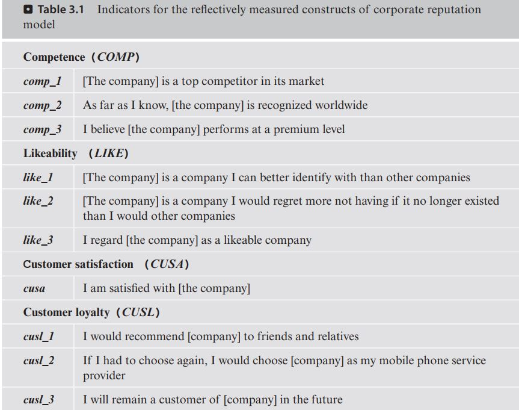

Indicators for the reflectively measured constructs of corporate reputation model

Now that you are familiar with the reputation model, we will demonstrate the syntax used by SEMinR. Briefly, there are four steps to specify and estimate a structural equation model using SEMinR:

1. Loading and cleaning the data
2. Specifying the measurement models
3. Specifying the structural model
4. Estimating, bootstrapping, and summarizing the model